# 20200526-rethinking-chpt1_win10

diaorch

5/26/2020

## Installation of `rstan` on a Windows 10 machine

Below is a breakdown of steps needed to install the `rethinking` package with a freshly `R` and `RStudio` installation, starting from installing the dependencies. Codes are included below the step list.

1. install `Rtools`: download `Rtools` from and follow the instruction on the [CRAN “Using Rtools40 on Windows” page](https://cran.r-project.org/bin/windows/Rtools/), take notice to check if the version of `RTools` is compatible with *your* `R` version. Also, to “restart R” as instructed, assuming you are using `RStudio`, you would need to quit and reopen the RStudio, and only restarting the R session within RStudio would not update the path.
2. install `devtools` if needed, you can check by running `find.package('devtools')`. If the package is not found (e.g. output `Error in find.package('devtools') : there is no package called ‘devtools’`), install by running `install.packages('devtools)`.
3. load `devtools` and verify `Rtools` installation by running `find_rtools()`. This step is ordered as such because the function `find_rtools()` is in the `devtools` package.
4. install `RStan` by running `install.packages("rstan", repos = "https://cloud.r-project.org/", dependencies = TRUE)`. This actually installs `RStan` from source, which is the reason for all previous steps needed in Windows.
5. install `rethinking` from source (GitHub) by running `devtools::install_github('rmcelreath/rethinking')`

```r
# step 1
# download and install RTools40 from CRAN Rtools website, not shown
# put the location of the Rtools make utilities (bash, make, etc) on the PATH
# there are multiple ways to do it, one way is to run the next line in R
writeLines('PATH="${RTOOLS40_HOME}\\usr\\bin;${PATH}"', con = '~/.Renviron')
# restart R - restart the whole RStudio if in one, then verify the path
Sys.which('make')
## "C:\\rtools40\\usr\\bin\\make.exe"

# step 2
find.package('devtools')
## Error in find.package('devtools') : there is no package called ‘devtools’
if(!require('devtools')){
    install.packages('devtools', dependencies = TRUE)
}
## 20200526, Win10, the package `backports` needed to be explicitly installed
## for `devtools` to be correctly loaded
## I suspect that is a compatibility issue in `backports` with R 4.0
## when prompted to choose whether to install from source instead of binary,
## confirm to use the source (the source is of later versioni than the binary)
# install.packages('backports')

# step 3
library('devtools')
find_rtools()

# step 4
install.packages('rstan',
                 repos = 'https://cloud.r-project.org/', dependencies = TRUE)
library('rstan')

# step 5
devtools::install_github('rmcelreath/rethinking')
library(rethinking)
help(package=rethinking)
## verify successful installation if in-system help opens up
```

## Linear regression with two independent categorical variables - an example with `stats::lm()`, `brms`, and `rethinking`

Consider a linear regression model in the form of:

$$y_i = \beta_0 + \beta_1 x_{1,i} + \beta_2 x_{2,i} + \beta_3 x_{1,i} x_{2,i} + \epsilon_{i}$$

### Data simulation

What information we need for each sample as a starting point is:

1. “treated/untreated” by drug A: as a integer, in this case binary (0 or 1)
2. “treated/untreated” by drug B: as a integer, in this case binary (0 or 1)
3. “measurement of treatment effects”: as a float, in this case randomly generated

```r
set.seed(13)
drugA <- c(rep(0, 10), rep(1, 10))
drugB <- rep(c(rep(0, 5), rep(1, 5)), 2)
effect <- c(rnorm(5), rnorm(5) + 2, rnorm(5) + 3, rnorm(5) + 10)
alldat <- data.frame(
    'drugA' = drugA, 'drugB' = drugB, 'effect' = effect
)
print(alldat)
```

```
##    drugA drugB     effect
## 1      0     0  0.5543269
## 2      0     0 -0.2802719
## 3      0     0  1.7751634
## 4      0     0  0.1873201
## 5      0     0  1.1425261
## 6      0     1  2.4155261
## 7      0     1  3.2295066
## 8      0     1  2.2366797
## 9      0     1  1.6346172
## 10     0     1  3.1051443
## 11     1     0  1.9064060
## 12     1     0  3.4618709
## 13     1     0  1.6390155
## 14     1     0  1.1439728
## 15     1     0  2.5601446
## 16     1     1  9.8060531
## 17     1     1 11.3964315
## 18     1     1 10.1006632
## 19     1     1  9.8855612
## 20     1     1 10.7022252
```

### Linear regression with two independent categorical variables - with `stats::lm()`

```r
twovarMod <- lm(effect ~ drugA + drugB + drugA:drugB, data = alldat)
print(summary(twovarMod))
```

```
##
## Call:
## lm(formula = effect ~ drugA + drugB + drugA:drugB, data = alldat)
##
## Residuals:
##     Min      1Q  Median      3Q     Max
## -0.9983 -0.4953 -0.1787  0.4953  1.3196
##
## Coefficients:
##             Estimate Std. Error t value Pr(>|t|)
## (Intercept)   0.6758     0.3414   1.979  0.06524 .
## drugA         1.4665     0.4828   3.037  0.00785 **
## drugB         1.8485     0.4828   3.828  0.00148 **
## drugA:drugB   6.3874     0.6828   9.354 6.89e-08 ***
## ---
## Signif. codes:  0 '***' 0.001 '**' 0.01 '*' 0.05 '.' 0.1 ' ' 1
##
## Residual standard error: 0.7634 on 16 degrees of freedom
## Multiple R-squared:  0.9685, Adjusted R-squared:  0.9626
## F-statistic:   164 on 3 and 16 DF,  p-value: 3.191e-12
```

### Linear regression with two independent categorical variables - with `brms`

Fitting a Bayesian Generalized Linear Multivariate Model:

```r
library('brms')
alldatFactor <- data.frame(
    'drugA' = factor(drugA, levels = c(0, 1)), 'drugB' = factor(drugB, levels = c(0, 1)), 'effect' = effect
)
brmCatMod <- brm(effect ~ drugA + drugB + drugA:drugB, data = alldatFactor)
```

As an interesting side note: it took me a good while for the BRMS fitting run to get pass compiling the C++ model. (There is always a balance between the result performance and the speed.)

```r
print(summary(brmCatMod))
```

```
##  Family: gaussian
##   Links: mu = identity; sigma = identity
## Formula: effect ~ drugA + drugB + drugA:drugB
##    Data: alldatFactor (Number of observations: 20)
## Samples: 4 chains, each with iter = 2000; warmup = 1000; thin = 1;
##          total post-warmup samples = 4000
##
## Population-Level Effects:
##               Estimate Est.Error l-95% CI u-95% CI Rhat Bulk_ESS Tail_ESS
## Intercept         0.69      0.37    -0.01     1.42 1.00     2178     2267
## drugA1            1.46      0.52     0.40     2.54 1.00     1833     2035
## drugB1            1.83      0.53     0.77     2.91 1.00     2005     2151
## drugA1:drugB1     6.40      0.75     4.89     7.88 1.00     1594     2148
##
## Family Specific Parameters:
##       Estimate Est.Error l-95% CI u-95% CI Rhat Bulk_ESS Tail_ESS
## sigma     0.83      0.16     0.58     1.22 1.00     1956     2522
##
## Samples were drawn using sampling(NUTS). For each parameter, Bulk_ESS
## and Tail_ESS are effective sample size measures, and Rhat is the potential
## scale reduction factor on split chains (at convergence, Rhat = 1).
```

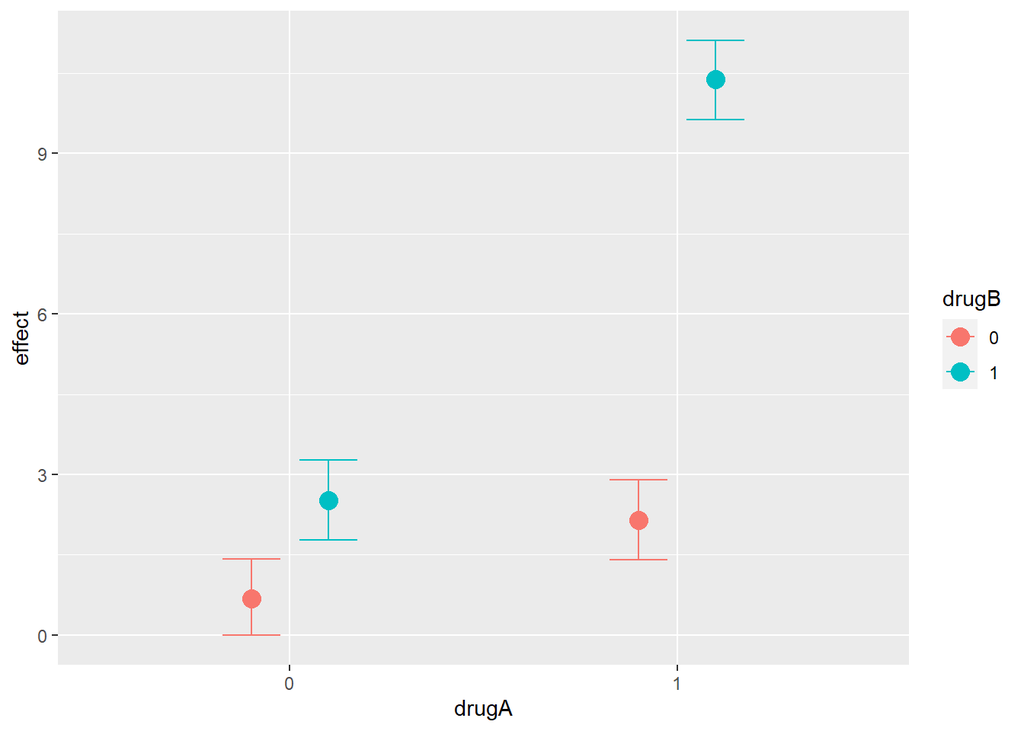

```r
conditional_effects(brmCatMod, effects = 'drugA:drugB')
```

```r
# to see all effects (both individual and two-ways)
# remove the argument effects from the command above
```

`R` is always interesting when it comes to factors. What if we don’t convert the `drugA` and `drugB` column from numerics to factors? As you can see in the `lm()` it does not cause *major* hiccup but in `brms::brm()`, if we do the following instead:

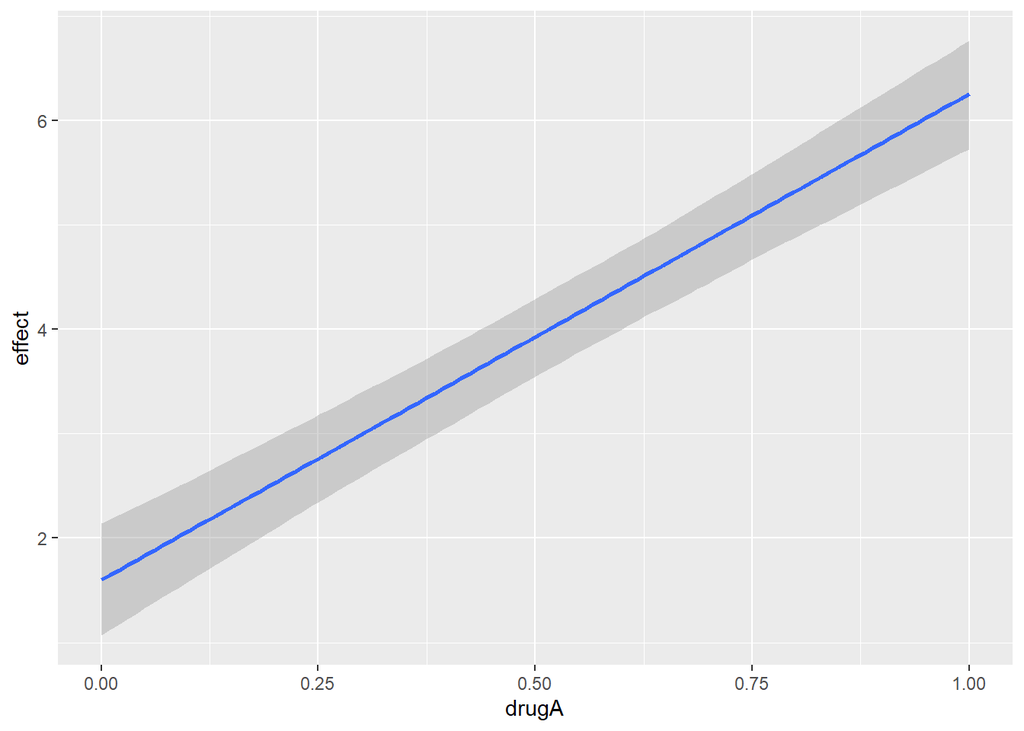

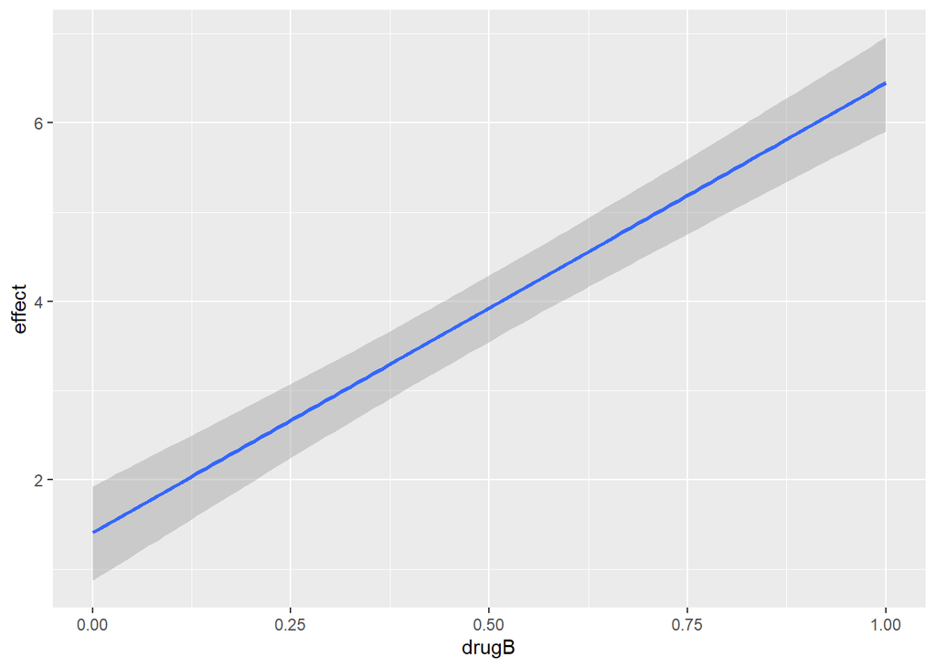

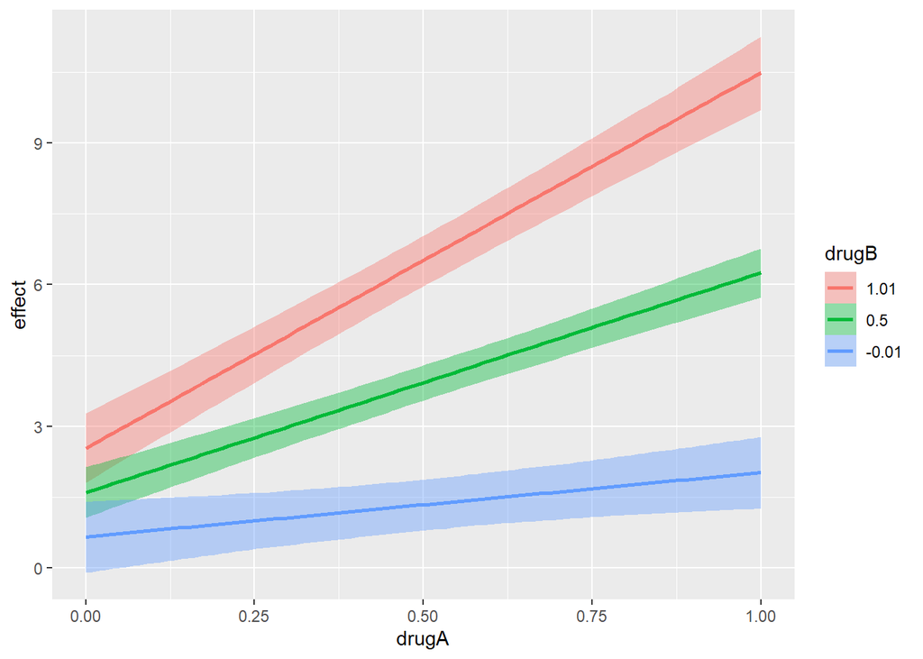

```r
brmMod <- brm(effect ~ drugA + drugB + drugA:drugB, data = alldat, silent = TRUE, refresh = 0)
conditional_effects(brmMod)
```

Notice the types of figures compared to the previous results with categorical inputs.

If we check the chains:

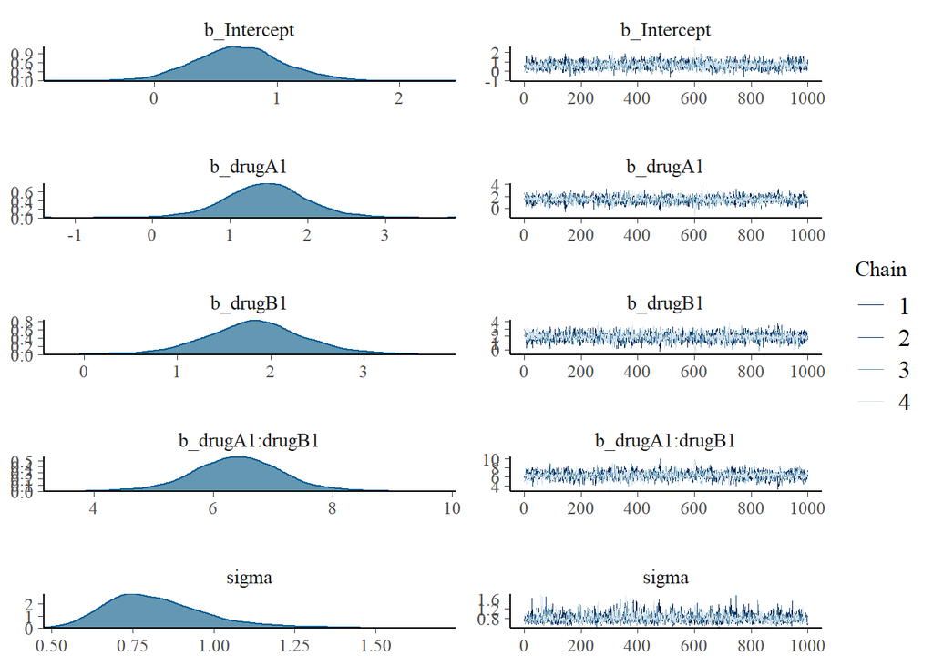

```r
plot(brmCatMod)
```

### Linear regression with two independent categorical variables - with `rethinking`

The function renaming here is explained as in the [README for the `rethinking` package](https://github.com/rmcelreath/rethinking/blob/master/README.md):

> It was renamed, because the name map was misleading. This function produces quadratic approximations of the posterior distribution, not just maximum a posteriori (MAP) estimates.

Consider model:

$$y_i \sim \text{Normal}(\mu_i, \sigma) \\
\mu_i = \alpha + \beta_a x_{a,i} + \beta_b x_{b,i} + \beta_{ab} x_{a,i} + x_{a,i} \\
\alpha \sim \text{Normal}(0, 5) \\
\beta \sim \text{Normal}(0, 5)\\
\sigma \sim \text{Uniform}(0, 5)\\$$

In `rethinking`, a prior of `a ~ dnorm(0, 10)` translates to `dnorm(a, mean = 0, sd = 10)`.

```r
library('rethinking')
fit5 <- quap(
    alist(
        effect ~ dnorm(mu, sigma),
        mu <- a + ba * drugA + bb * drugB + bab * drugA * drugB,
        a ~ dnorm(0, 5),
        ba ~ dnorm(0, 5), bb ~ dnorm(0, 5), bab ~ dnorm(0, 5),
        sigma ~ dunif(0, 5)),
    data = alldat)
fit10 <- quap(
    alist(
        effect ~ dnorm(mu, sigma),
        mu <- a + ba * drugA + bb * drugB + bab * drugA * drugB,
        a ~ dnorm(0, 10),
        ba ~ dnorm(0, 10), bb ~ dnorm(0, 10), bab ~ dnorm(0, 10),
        sigma ~ dunif(0, 5)),
    data = alldat)
```

### Side-by-side comparison of the fittings

```r
# stats::lm()
print(twovarMod$coefficients)
```

```
## (Intercept)       drugA       drugB drugA:drugB
##   0.6758129   1.4664690   1.8484818   6.3874230
```

```r
# brms::brm()
print(fixef(brmCatMod))
```

```
##                Estimate Est.Error         Q2.5    Q97.5
## Intercept     0.6882101 0.3650103 -0.007841364 1.424292
## drugA1        1.4597516 0.5241175  0.399393201 2.535100
## drugB1        1.8344066 0.5319034  0.773262019 2.912868
## drugA1:drugB1 6.3997870 0.7503707  4.891973192 7.879371
```

```r
# rethinking::quap()
print(rethinking::precis(fit5))
```

```
##            mean        sd      5.5%     94.5%
## a     0.6623684 0.3032689 0.1776862 1.1470506
## ba    1.4978976 0.4281662 0.8136053 2.1821898
## bb    1.8784898 0.4281563 1.1942133 2.5627662
## bab   6.3158562 0.6043715 5.3499539 7.2817585
## sigma 0.6830699 0.1080779 0.5103406 0.8557992
```

```r
print(rethinking::precis(fit10))
```

```
##            mean        sd      5.5%     94.5%
## a     0.6723521 0.3048106 0.1852060 1.1594983
## ba    1.4744940 0.4308715 0.7858781 2.1631099
## bb    1.8561544 0.4308709 1.1675396 2.5447693
## bab   6.3692433 0.6090064 5.3959334 7.3425532
## sigma 0.6828402 0.1079704 0.5102826 0.8553978
```

## Supplementary information

### Installation of package `brms`

The package `brms` is available on CRAN. Install by running `install.packages('brms')` and verify the installation by running `library('brms')`.

## For future references

### The session info when the documentation is written

The current version is written on 20200526, with a recent `R 4.0` release.

Before starting the installation process, out of personal maintenance preferences, I removed `R` (then version 3.6), RStudio, and `Rtools` and installed the latest versions of `R` (now version 4.0) and RStudio (now version 1.3.959). For `Rtools`, notice the version compatibility with `R 4.0`. `Rtools40` installation is described above.

As a reference point for the environment-specific fixes above, I am recording my 20200526 session information for the “this works on my machine” setting, to be compared to *your* session information if needed.

My 20200526 session info:

```r
> sessionInfo()
R version 4.0.0 (2020-04-24)
Platform: x86_64-w64-mingw32/x64 (64-bit)
Running under: Windows 10 x64 (build 18362)

Matrix products: default

locale:
[1] LC_COLLATE=English_United States.1252  LC_CTYPE=English_United States.1252
[3] LC_MONETARY=English_United States.1252 LC_NUMERIC=C
[5] LC_TIME=English_United States.1252

attached base packages:
[1] parallel  stats     graphics  grDevices utils     datasets  methods   base

other attached packages:
[1] rethinking_2.01    dagitty_0.2-2      rstan_2.19.3       ggplot2_3.3.0
[5] StanHeaders_2.19.2 devtools_2.3.0     usethis_1.6.1

loaded via a namespace (and not attached):
 [1] Rcpp_1.0.4.6       mvtnorm_1.1-0      lattice_0.20-41    prettyunits_1.1.1
 [5] ps_1.3.3           assertthat_0.2.1   rprojroot_1.3-2    digest_0.6.25
 [9] packrat_0.5.0      V8_3.0.2           R6_2.4.1           backports_1.1.7
[13] stats4_4.0.0       evaluate_0.14      coda_0.19-3        pillar_1.4.4
[17] rlang_0.4.6        curl_4.3           rstudioapi_0.11    callr_3.4.3
[21] rmarkdown_2.1      desc_1.2.0         loo_2.2.0          munsell_0.5.0
[25] compiler_4.0.0     xfun_0.14          pkgconfig_2.0.3    pkgbuild_1.0.8
[29] shape_1.4.4        htmltools_0.4.0    tidyselect_1.1.0   tibble_3.0.1
[33] gridExtra_2.3      matrixStats_0.56.0 fansi_0.4.1        crayon_1.3.4
[37] dplyr_0.8.5        withr_2.2.0        MASS_7.3-51.5      grid_4.0.0
[41] jsonlite_1.6.1     gtable_0.3.0       lifecycle_0.2.0    magrittr_1.5
[45] scales_1.1.1       cli_2.0.2          fs_1.4.1           remotes_2.1.1
[49] testthat_2.3.2     ellipsis_0.3.1     vctrs_0.3.0        boot_1.3-24
[53] tools_4.0.0        glue_1.4.1         purrr_0.3.4        rsconnect_0.8.16
[57] processx_3.4.2     pkgload_1.0.2      yaml_2.2.1         inline_0.3.15
[61] colorspace_1.4-1   sessioninfo_1.1.1  memoise_1.1.0      knitr_1.28
```

[session information not shown]

### Do-dos:

1. add resource links
2. add support to other operation systems
3. add repo-level “getting started with R and RStudio” and “Some struggles with Windows and how to solve hopefully under 5 hours”
4. double check encoding and line breaks since this is written on my Win10 machine
5. add “slides” for chapter 1 (and organize: as a separate file?)
6. add pointers to lab meeting slides on regression (20200518) and BRMS (20190722)
7. add model selection examples in BRMS?
8. add references to detailed contents as the contents build up for the following chapters